# Computational Mathematics Final

Mary Anna Kivenson

December 8, 2019

## Problem 1

### Random Variables

Using R, generate a random variable X that has 10,000 random uniform numbers from 1 to N, where N can be any number of your choosing greater than or equal to 6.

```r
##generate a random variable X that has 10,000 random uniform numbers from 1 to N, where N can be any number of your choosing greater than or equal to 6
rand_var = function(n) runif(10000,1, n)

##set n equal to 6
n = 6

X <- rand_var(n)
summary(X)
```

```
##    Min. 1st Qu.  Median    Mean 3rd Qu.    Max.
##   1.000   2.239   3.529   3.519   4.794   6.000
```

Then generate a random variable Y that has 10,000 random normal numbers with a mean of:
$$\mu = \sigma = \frac{(N+1)}{2}$$

```r
#generate a random variable Y that has 10,000 random normal numbers with a mean and sd of mu
mu = (n + 1)/2
Y <- rnorm(10000,mean=mu, sd = mu)
summary(Y)
```

```
##    Min. 1st Qu.  Median    Mean 3rd Qu.    Max.
##  -9.482   1.143   3.515   3.490   5.882  16.238
```

### Probability

5 points. Calculate as a minimum the below probabilities a through c. Assume the small letter “x” is estimated as the median of the X variable, and the small letter “y” is estimated as the 1st quartile of the Y variable. Interpret the meaning of all probabilities.

```r
#median of X variable
x <- quantile(X)[[3]]
print(x)
```

```
## [1] 3.529372
```

```r
#1st quartile of Y variable
y <- quantile(Y)[[2]]
print(y)
```

```
## [1] 1.143492
```

#### P(X>x | X>y)

This is the probability that X is greater than the median of X given that X is greater than the first quartile of Y.

Since the random variables are independent, the conditional probability will be:

$$P(X>x | X>y) = \frac{P(X>x, X>y)}{P(X>y)} = \frac{P(X>x) \times P(X>y)}{P(X>y)} = P(X>x)$$

P(X>x) = 0.5 P(X>x | X>y) = 0.5

*Experimental*

```r
mean(X>x)*mean(X>y)/mean(X>y)
```

```
## [1] 0.5
```

#### P(X>x, Y>y)

This is the probability that X is greater than its median and Y is greater than its first quartile Since the median of the variable is its midpoint, P(X>x) = 0.5. Similarly, since y is the first quartile, P(Y>y) = 0.75.

$$P(X>x, Y>y) = P(X>x) \times P(Y>y) = 0.5 \times 0.75 = 0.375$$

*Experimental*

```r
mean(X>x)*mean(Y>y)
```

```
## [1] 0.375
```

#### (X<x | X>y)

This is the probability that X is less than its median given that it is greater than the first quartile of y.

$$P(X<x | X>y) = \frac{P(X<x, X>y)}{P(X>y)} = \frac{P(X<x) \times P(X>y)}{P(X>y)} = P(X<x) = 0.5$$

This example probability is the inverse of example a, so it will be equal to 1 - P(X>x|X>y) = 0.5

*Experimental*

```r
mean(X<x)*mean(X>y)/mean(X>y)
```

```
## [1] 0.5
```

### Marginal / Joint

5 points.  
Investigate whether P(X>x and Y>y)=P(X>x)P(Y>y) by building a table and evaluating the marginal and joint probabilities.

Marginal Probabilities: The probability of a single event.

- P(X>x)
- P(X<x)
- P(Y>y)
- P(Y<y)

```r
marginal <- cbind(cbind(mean(X>x), mean(X<x)),cbind(mean(Y>y), mean(Y<y)))
colnames(marginal) <- c('P(X>x)','P(X<x)','P(Y>y)','P(Y<y)')
#rownames(marginal) <- c('P(Y>y)','P(Y<y)')
marginal
```

```
##      P(X>x) P(X<x) P(Y>y) P(Y<y)
## [1,]    0.5    0.5   0.75   0.25
```

Joint probabilities: The probability of two events occuring simultaneously.

```r
joint <- rbind(cbind(mean(X>x)*mean(Y>y), mean(X<x)*mean(Y>y)),cbind(mean(Y<y)*mean(X>x), mean(Y<y)*mean(X<x)))
colnames(joint) <- c('P(X>x)','P(X<x)')
rownames(joint) <- c('P(Y>y)','P(Y<y)')
joint
```

```
##        P(X>x) P(X<x)
## P(Y>y)  0.375  0.375
## P(Y<y)  0.125  0.125
```

### Independence

5 points.  
Check to see if independence holds by using Fisher’s Exact Test and the Chi Square Test. What is the difference between the two? Which is most appropriate?

*Fisher’s Exact Test*

Tests independence of rows and columns in a contingency table with fixed marginal probabilities. According to the test, since the p-value = 1, we fail to reject the null hypothesis that rows and columns are independent.

```r
# fisher test - multiplied by 10000 (amount of trials) to remove error 'x' has been rounded to integer: Mean relative difference: 1
fisher.test(joint*10000, alternative = "two.sided", conf.int = FALSE, conf.level = 0.95)
```

```
##
##  Fisher's Exact Test for Count Data
##
## data:  joint * 10000
## p-value = 1
## alternative hypothesis: true odds ratio is not equal to 1
## sample estimates:
## odds ratio
##          1
```

*Chi Square Test*

Tests independence of rows and columns - whether the probability distributions of X and Y are not affected by each other. According to the test, since the p-value = 1, we fail to reject the null hypothesis that rows and columns are independent.

```r
library(MASS)
# chisq test - multiplied by 10000 (amount of trials) to remove error
chisq.test(joint*10000)
```

```
##
##  Pearson's Chi-squared test
##
## data:  joint * 10000
## X-squared = 0, df = 1, p-value = 1
```

*Conclusion*

The difference between the Chi-squared test and Fisher’s exact test is that the latter is more accurate while the former is an approximation. However, in this situation, since we have 10,000 random variables, the Chi-square test is more appropriate; the Chi-square test is better for large sample sizes.

## Problem 2

You are to register for Kaggle.com (free) and compete in the House Prices: Advanced Regression Techniques competition. https://www.kaggle.com/c/house-prices-advanced-regression-techniques

```r
#get datasets
test <- read.csv(file = "https://raw.githubusercontent.com/mkivenson/Computational-Mathematics/master/Final%20Project/test.csv")
train <- read.csv(file = "https://raw.githubusercontent.com/mkivenson/Computational-Mathematics/master/Final%20Project/train.csv")
```

### Descriptive and Inferential Statistics

#### Univariate Descriptive Statistics

Provide univariate descriptive statistics and appropriate plots for the training data set.

```r
summary(train$SalePrice)
```

```
##    Min. 1st Qu.  Median    Mean 3rd Qu.    Max.
##   34900  129975  163000  180921  214000  755000
```

#### Scatterplot Matrix

Provide a scatterplot matrix for at least two of the independent variables and the dependent variable.

```r
library(ggplot2)
colnames(train)
```

```
##  [1] "Id"            "MSSubClass"    "MSZoning"      "LotFrontage"
##  [5] "LotArea"       "Street"        "Alley"         "LotShape"
##  [9] "LandContour"   "Utilities"     "LotConfig"     "LandSlope"
## [13] "Neighborhood"  "Condition1"    "Condition2"    "BldgType"
## [17] "HouseStyle"    "OverallQual"   "OverallCond"   "YearBuilt"
## [21] "YearRemodAdd"  "RoofStyle"     "RoofMatl"      "Exterior1st"
## [25] "Exterior2nd"   "MasVnrType"    "MasVnrArea"    "ExterQual"
## [29] "ExterCond"     "Foundation"    "BsmtQual"      "BsmtCond"
## [33] "BsmtExposure"  "BsmtFinType1"  "BsmtFinSF1"    "BsmtFinType2"
## [37] "BsmtFinSF2"    "BsmtUnfSF"     "TotalBsmtSF"   "Heating"
## [41] "HeatingQC"     "CentralAir"    "Electrical"    "X1stFlrSF"
## [45] "X2ndFlrSF"     "LowQualFinSF"  "GrLivArea"     "BsmtFullBath"
## [49] "BsmtHalfBath"  "FullBath"      "HalfBath"      "BedroomAbvGr"
## [53] "KitchenAbvGr"  "KitchenQual"   "TotRmsAbvGrd"  "Functional"
## [57] "Fireplaces"    "FireplaceQu"   "GarageType"    "GarageYrBlt"
## [61] "GarageFinish"  "GarageCars"    "GarageArea"    "GarageQual"
## [65] "GarageCond"    "PavedDrive"    "WoodDeckSF"    "OpenPorchSF"
## [69] "EnclosedPorch" "X3SsnPorch"    "ScreenPorch"   "PoolArea"
## [73] "PoolQC"        "Fence"         "MiscFeature"   "MiscVal"
## [77] "MoSold"        "YrSold"        "SaleType"      "SaleCondition"
## [81] "SalePrice"
```

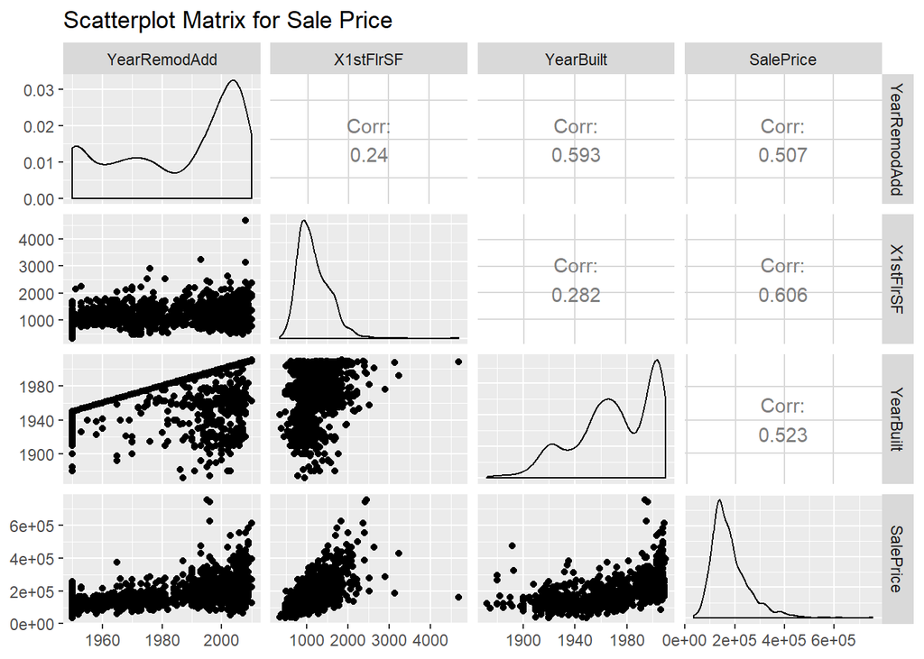

```r
library(ggplot2)
library(GGally)
ggpairs(train, columns=c(21,44,20,81), aes()) +
  ggtitle("Scatterplot Matrix for Sale Price")
```

#### Correlation Matrix

Derive a correlation matrix for any three quantitative variables in the dataset.

This correlation matrix will show OverallQual, OverallCond, LotArea, and SalePrice.

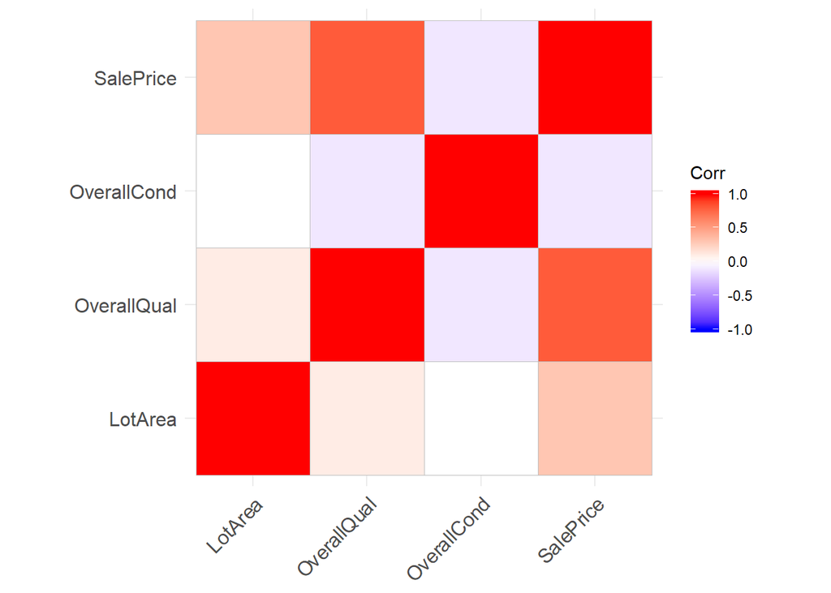

```r
library(ggcorrplot)
corr <- round(cor(train[, c(5,18,19,81)]), 1)
ggcorrplot(corr)
```

#### Hypothesis

Test the hypotheses that the correlations between each pairwise set of variables is 0 and provide an 80% confidence interval. Discuss the meaning of your analysis. Would you be worried about familywise error? Why or why not?

```r
#LotArea and OverallQual
c1 <- cor.test(x = corr[1,], y = corr[2,], method = "pearson", conf.level = 0.8)
print(paste("P-value:", c1$p.value, " | ", "Conf Int:", c1$conf.int[1], "-", c1$conf.int[2]))
```

```
## [1] "P-value: 0.736136559675603  |  Conf Int: -0.914083312120158 - 0.766297160828907"
```

```r
#LotArea and OverallCond
c2 <- cor.test(x = corr[1,], y = corr[3,], method = "pearson", conf.level = 0.8)
print(paste("P-value:", c2$p.value, " | ", "Conf Int:", c2$conf.int[1], "-", c2$conf.int[2]))
```

```
## [1] "P-value: 0.558189701264645  |  Conf Int: -0.942057888073233 - 0.667972762518936"
```

```r
#LotArea and SalePrice
c3 <- cor.test(x = corr[1,], y = corr[4,], method = "pearson", conf.level = 0.8)
print(paste("P-value:", c3$p.value, " | ", "Conf Int:", c3$conf.int[1], "-", c3$conf.int[2]))
```

```
## [1] "P-value: 0.97023203007135  |  Conf Int: -0.864611132667099 - 0.84878057107682"
```

```r
#OverallQual and OverallCond
c4 <- cor.test(x = corr[2,], y = corr[3,], method = "pearson", conf.level = 0.8)
print(paste("P-value:", c4$p.value, " | ", "Conf Int:", c4$conf.int[1], "-", c4$conf.int[2]))
```

```
## [1] "P-value: 0.251449188515929  |  Conf Int: -0.978078315801338 - 0.302165269266376"
```

```r
#OverallQual and SalePrice
c5 <- cor.test(x = corr[2,], y = corr[4,], method = "pearson", conf.level = 0.8)
print(paste("P-value:", c5$p.value, " | ", "Conf Int:", c5$conf.int[1], "-", c5$conf.int[2]))
```

```
## [1] "P-value: 0.0669468207577246  |  Conf Int: 0.379886616460239 - 0.994676257665829"
```

```r
#OverallCond and SalePrice
c6 <- cor.test(x = corr[3,], y = corr[4,], method = "pearson", conf.level = 0.8)
print(paste("P-value:", c6$p.value, " | ", "Conf Int:", c6$conf.int[1], "-", c6$conf.int[2]))
```

```
## [1] "P-value: 0.14759924204137  |  Conf Int: -0.987793842434317 - 0.016681514522772"
```

The correlation tests show that the correlations between OverallQual & SalePrice is significant, since the confidence interval does not include a correlation of 0.

Familywise error, or Type I error, is the probability of making a false conclusion. We should be worried about familywise error - the probability of it occuring is equal to the significance value (0.20)

### Linear Algebra and Correlation

#### Precision Matrix

Invert your correlation matrix from above. (This is known as the precision matrix and contains variance inflation factors on the diagonal.)

I used the built-in inv() function in R to invert the correlation matrix.

```r
library(matlib)
precision <- inv(corr)
precision
```

```
##
## [1,]  1.16951380  0.45335085 -0.02628121 -0.71616294
## [2,]  0.45335085  2.95663601  0.04599212 -2.49671485
## [3,] -0.02628121  0.04599212  1.01182654  0.07227332
## [4,] -0.71616294 -2.49671485  0.07227332  3.21944809
```

Multiply the correlation matrix by the precision matrix, and then multiply the precision matrix by the correlation matrix.

The product of these matrix operations is the identity matrix.

```r
round(precision %*% corr,2)
```

```
##      LotArea OverallQual OverallCond SalePrice
## [1,]       1           0           0         0
## [2,]       0           1           0         0
## [3,]       0           0           1         0
## [4,]       0           0           0         1
```

```r
round(corr %*% precision)
```

```
##
## LotArea     1 0 0 0
## OverallQual 0 1 0 0
## OverallCond 0 0 1 0
## SalePrice   0 0 0 1
```

#### LU Decomposition

Conduct LU decomposition on the matrix.

I used the function that I created in a previous homework assignment to perform LU decomposition.

```r
lu <- function(matrix){

  n = nrow(matrix)

  lower = matrix((c(1:n)*0), nrow=n, ncol=n)
  upper = matrix((c(1:n)*0), nrow=n, ncol=n)

  for(i in (1:n)) {
    for(k in (i:n)) {
      sum = 0
      for(j in (1:i)) {
        sum = sum + (lower[i,j] * upper[j, k])
      }
      upper[i, k] = matrix[i, k] - sum
    }
    for(k in (i:n)) {
      if(i == k) {
        lower[i, i] = 1
      } else {
        sum = 0
        for(j in (1:i)) {
          sum = sum + (lower[k, j] * upper[j, i])
        }
        lower[k, i] = (matrix[k, i] - sum) / upper[i, i]
      }
    }
  }

  return(list(lower, upper))
}


lu(corr)
```

```
## [[1]]
##      [,1]       [,2]        [,3] [,4]
## [1,]  1.0  0.0000000  0.00000000    0
## [2,]  0.1  1.0000000  0.00000000    0
## [3,]  0.0 -0.1010101  1.00000000    0
## [4,]  0.3  0.7777778 -0.02244898    1
##
## [[2]]
##      [,1] [,2]      [,3]        [,4]
## [1,]    1 0.10  0.000000  0.30000000
## [2,]    0 0.99 -0.100000  0.77000000
## [3,]    0 0.00  0.989899 -0.02222222
## [4,]    0 0.00  0.000000  0.31061224
```

```r
lu(precision)
```

```
## [[1]]
##             [,1]        [,2] [,3] [,4]
## [1,]  1.00000000  0.00000000  0.0    0
## [2,]  0.38764045  1.00000000  0.0    0
## [3,] -0.02247191  0.02020202  1.0    0
## [4,] -0.61235955 -0.79797980  0.1    1
##
## [[2]]
##          [,1]      [,2]        [,3]       [,4]
## [1,] 1.169514 0.4533509 -0.02628121 -0.7161629
## [2,] 0.000000 2.7808989  0.05617978 -2.2191011
## [3,] 0.000000 0.0000000  1.01010101  0.1010101
## [4,] 0.000000 0.0000000  0.00000000  1.0000000
```

### Calculus-Based Probability & Statistics

#### Shift Distribution

Many times, it makes sense to fit a closed form distribution to data. Select a variable in the Kaggle.com training dataset that is skewed to the right, shift it so that the minimum value is absolutely above zero if necessary.

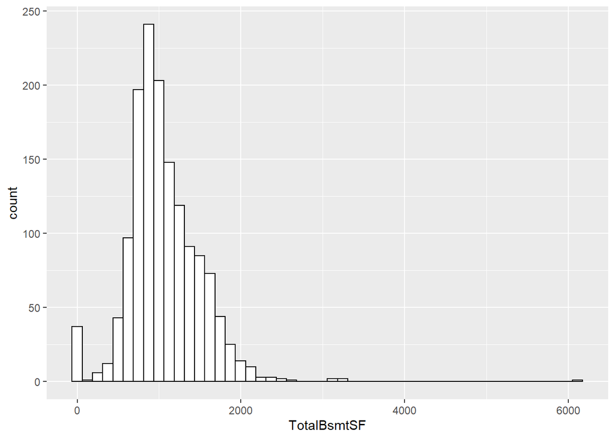

```r
# Draw with black outline, white fill
ggplot(train, aes(x=TotalBsmtSF)) +
    geom_histogram(bins=50, colour="black", fill="white")
```

```r
summary(train$TotalBsmtSF)
```

```
##    Min. 1st Qu.  Median    Mean 3rd Qu.    Max.
##     0.0   795.8   991.5  1057.4  1298.2  6110.0
```

#### Exponential Probability Density

Then load the MASS package and run fitdistr to fit an exponential probability density function. (See https://stat.ethz.ch/R-manual/R-devel/library/MASS/html/fitdistr.html ). Find the optimal value of lambda for this distribution, and then take 1000 samples from this exponential distribution using this value (e.g., rexp(1000, lambda)).

```r
lambda <- fitdistr(train$TotalBsmtSF, "exponential")$estimate[[1]]
lambda
```

```
## [1] 0.0009456896
```

```r
exp_samples <- rexp(1000, lambda)
```

#### Plot Histogram

Plot a histogram and compare it with a histogram of your original variable. Using the exponential pdf, find the 5th and 95th percentiles using the cumulative distribution function (CDF). Also generate a 95% confidence interval from the empirical data, assuming normality. Finally, provide the empirical 5th percentile and 95th percentile of the data. Discuss.

This new histogram has the shape of an exponential distribution, while the original variable, though skewed, is closer to a normal distribution.

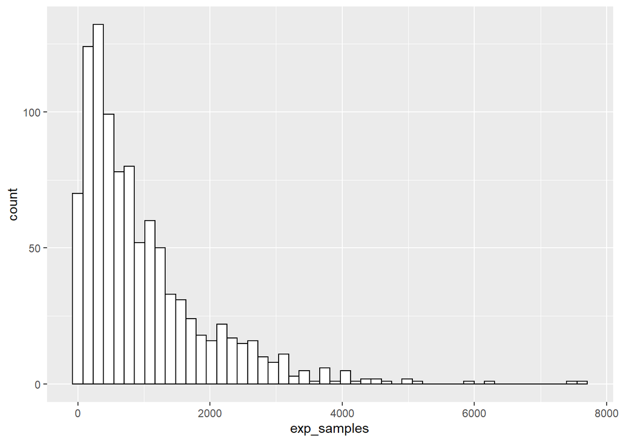

```r
ggplot(as.data.frame(exp_samples), aes(x=exp_samples)) +
    geom_histogram(bins=50, colour="black", fill="white")
```

*95% Confidence*

```r
library(EnvStats)
eexp(train$TotalBsmtSF, ci = TRUE, conf.level = 0.95)
```

```
##
## Results of Distribution Parameter Estimation
## --------------------------------------------
##
## Assumed Distribution:            Exponential
##
## Estimated Parameter(s):          rate = 0.0009456896
##
## Estimation Method:               mle/mme
##
## Data:                            train$TotalBsmtSF
##
## Sample Size:                     1460
##
## Confidence Interval for:         rate
##
## Confidence Interval Method:      Exact
##
## Confidence Interval Type:        two-sided
##
## Confidence Level:                95%
##
## Confidence Interval:             LCL = 0.0008977972
##                                  UCL = 0.0009948089
```

*CDF vs Emperical percentials*

```r
#CDF
quantile(exp_samples, c(.05, .95))
```

```
##         5%        95%
##   60.57627 2921.96747
```

```r
#Emperical
quantile(train$TotalBsmtSF, c(.05, .95))
```

```
##     5%    95%
##  519.3 1753.0
```

## Modeling

Build some type of multiple regression model and submit your model to the competition board. Provide your complete model summary and results with analysis. Report your Kaggle.com user name and score.

Kaggle Account: [mkivenson](https://www.kaggle.com/mkivenson/competitions)

Score: 0.13507

Link to regression model: [Regression Model Notebook](https://nbviewer.jupyter.org/github/mkivenson/Computational-Mathematics/blob/master/Final%20Project/Multiple%20Regression.ipynb)